# Tutorial: Simulation-based power analysis for fixed effects models using pilot data

Marc [Beer] BeerHamill, Ph.D.

2026-06-29

# Overview

This tutorial demonstrates how to conduct a simulation-based power analysis using pilot data in R. We use the publicly available ToothGrowth dataset as a worked example, treating it as pilot data from a factorial experiment in which guinea pigs received vitamin C via one of two supplement sources at one of three doses. The goal of the power analysis is to estimate the minimum per-group sample size required to detect pairwise differences among treatment group means with adequate statistical power in a follow-up experiment.

Power is estimated via parametric simulation, in which synthetic datasets are generated by drawing random samples from probability distributions parameterized by a pilot model’s estimated coefficients and residual variance. This approach assumes that the pilot model’s parameter estimates are the true values, and that the data-generating process in the follow-up experiment will match the structure encoded in the pilot model. This tutorial concerns fixed effects models; a companion tutorial covering mixed effects models with random effects is in preparation.

The tutorial is organized into two parts:

- Part 1 implements a power analysis based on a simple linear model, covering exploratory data analysis, model fitting and assumption checking, pairwise contrast testing via the `emmeans` package, parametric data simulation, and parallelized replicated simulation.
- Part 2 implements a robustness check by repeating the power analysis under a generalized least squares model with group-specific residual variances, fitted using the nlme package. The two approaches are then compared to assess whether the homoscedasticity assumption of the simple linear model materially affects the power conclusions.

Readers are assumed to have basic familiarity with linear models and R programming. The code is intended to be modular and adaptable to other experimental designs and modeling frameworks.

## Dependencies

This tutorial uses the renv package for dependency management. To restore the package environment used to produce this document, run the following code in the R console before knitting:

```r
renv::restore()
```

This will install all required packages at the versions specified in the lockfile. Once the environment is restored, the following chunk loads all required packages.

Note that one dependency, gghalves, is not available on CRAN and must be installed from GitHub. This is handled automatically by `renv::restore()`, but researchers installing packages manually should run remotes::install_github(“erocoar/gghalves”) instead.

```r
libs = c("knitr", "tidyverse", "ggplot2", "gghalves", "patchwork", "nlme", "emmeans", "parallel", "doParallel", "doRNG")
invisible(lapply(libs, library, character.only = TRUE))
```

# Part 1: Basic power analysis via `lm()`

## 1.1 Data exploration

Let’s load our practice dataset, which is the publicly available “ToothGrowth” dataset that accompanies R. In short, these data consist of odontoblast lengths measured from 60 guinea pigs that have received supplemental vitamin C via one of two sources of vitamin C (orange juice, OJ; or ascorbic acid, VC) at one of three doses (0.5, 1, or 2 mg/day). Thus, there are six treatment levels (e.g., OJ 0.5 mg/day). We’ll encode a new variable, “group” to store the combination of the supplement and dose to make some downstream tasks easier.

After doing so, let’s take a look at the data structure. The data are encoded in four columns: len (odontoblast length), supp (vitamin C supplement/source), dose, and the composite group factor we just created. We can also see that each group consists of 10 samples. Given the relatively small group sizes and the purpose of this walkthrough, we will regard these data as **pilot data**. That is, we will imagine that we have conducted a preliminary experiment whose data are intended to inform future work.

```r
data("ToothGrowth")
df = ToothGrowth; rm(ToothGrowth)

# modify field classes
df = df %>% mutate_at(vars(dose), as.factor)
df$group = paste0(df$supp, "_", df$dose)

# check data
knitr::kable(head(df))
```

| len | supp | dose | group |
| --- | --- | --- | --- |
| 4.2 | VC | 0.5 | VC_0.5 |
| 11.5 | VC | 0.5 | VC_0.5 |
| 7.3 | VC | 0.5 | VC_0.5 |
| 5.8 | VC | 0.5 | VC_0.5 |
| 6.4 | VC | 0.5 | VC_0.5 |
| 10.0 | VC | 0.5 | VC_0.5 |

```r
knitr::kable(df %>%
               group_by(group) %>%
               summarise(n = n()))
```

| group | n |
| --- | --- |
| OJ_0.5 | 10 |
| OJ_1 | 10 |
| OJ_2 | 10 |
| VC_0.5 | 10 |
| VC_1 | 10 |
| VC_2 | 10 |

It is always a good idea to explore data via visualization. Here, we’ll visualize the odontoblast length distributions within each of the six groups. There is a clear relationship between odontoblast length and dose for each of the supplements. Odontoblast lengths also appear to be shifted higher for OJ relative to VC across most doses, except perhaps a dose of 2 mg/day. Thus, we should at the very least include main effects of supplement and dose in any downstream statistical model(s). It also seems that the length difference between dose 2 and dose 0.5 (or 1) differs for OJ and VC. Specifically, the length increase from a dose of 0.5 to 2 is smaller for OJ than for VC. This suggests an interaction between the two variables; in other words, the effect of one variable depends on another variable. This should also inform our downstream models.

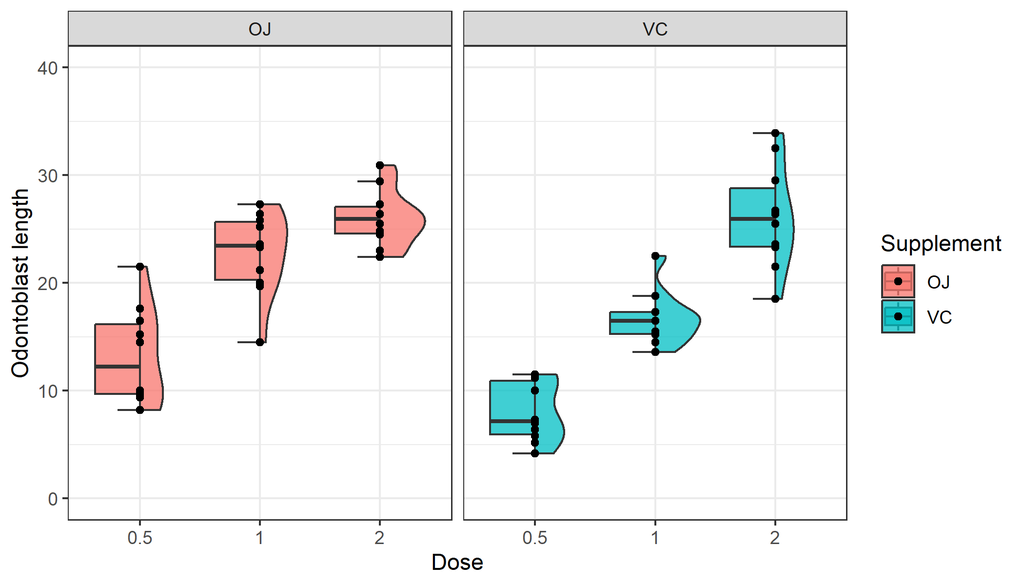

```r
# exploratory plot
ggplot(df, mapping=aes(x = dose, y = len, fill = supp))+
  geom_half_boxplot(side = "l", alpha = 0.75)+
  geom_half_violin(side = "r", alpha = 0.75)+
  geom_point()+
  scale_y_continuous(limits=c(0,40))+
  theme_bw()+
  labs(x = "Dose", y = "Odontoblast length", fill = "Supplement")+
  facet_wrap(~supp)
```

It also appears that odontoblast length variance may differ among groups, although it is difficult to tell at this sample size. Specifically, OJ-0.5 and VC-2 appear to have slightly greater variance than other groups. Non-constant error variance (i.e., heteroscedasticity) could be a problem for a simple linear model (or equivalently, an ANOVA), where constant error variance (i.e., homoscedasticity) is assumed. We can run a test for heteroscedasticity on the raw data without yet specifying a model. We’ll use the Bartlett test. We see here that the P value is around 0.23, indicating no evidence against homoscedasticity. However, with group sizes of 10, our power to reject homoscedasticity may be limited. Nevertheless, it appears reasonable to assume homoscedasticity for now, although we will implement an alternative power analysis that is more robust later on.

```r
# check for heteroscedasticity
bartlett_res = bartlett.test(len ~ group, data = df)
bartlett_res
```

```
##
##  Bartlett test of homogeneity of variances
##
## data:  len by group
## Bartlett's K-squared = 6.9273, df = 5, p-value = 0.2261
```

## 1.2 Fitting an initial model using pilot data

Let’s model our pilot data using a simple linear model with main effects of supplement and dose, as well as their interaction. This is mathematically equivalent to a two-way ANOVA with an interaction term. Viewing the summary, the main effects are all significant, and one of the two interaction terms (the last two coefficients) is significant.

The final two lines of code in this chunk grab two model components: we use `coef()` to grab the beta coefficients (fixed effects) and `sigma()` to grab the residual standard error. These two components are sufficient to inform a power analysis from these pilot data. However, the quality of the power analysis is contingent on model assumptions being met, which we address in the next chunk.

```r
pilot_mod = lm(len ~ supp * dose,
          data = df)
summary(pilot_mod)
```

```
##
## Call:
## lm(formula = len ~ supp * dose, data = df)
##
## Residuals:
##    Min     1Q Median     3Q    Max
##  -8.20  -2.72  -0.27   2.65   8.27
##
## Coefficients:
##              Estimate Std. Error t value Pr(>|t|)
## (Intercept)    13.230      1.148  11.521 3.60e-16 ***
## suppVC         -5.250      1.624  -3.233  0.00209 **
## dose1           9.470      1.624   5.831 3.18e-07 ***
## dose2          12.830      1.624   7.900 1.43e-10 ***
## suppVC:dose1   -0.680      2.297  -0.296  0.76831
## suppVC:dose2    5.330      2.297   2.321  0.02411 *
## ---
## Signif. codes:  0 '***' 0.001 '**' 0.01 '*' 0.05 '.' 0.1 ' ' 1
##
## Residual standard error: 3.631 on 54 degrees of freedom
## Multiple R-squared:  0.7937, Adjusted R-squared:  0.7746
## F-statistic: 41.56 on 5 and 54 DF,  p-value: < 2.2e-16
```

```r
# grab model parameters
pilot_fixeff = coef(pilot_mod) # obtain fixed effects
pilot_sigma = sigma(pilot_mod) # obtain residual standard error
```

## 1.3 Checking residuals

We previously used the Bartlett test to check for evidence against a null hypothesis of homoscedasticity and found none. Thus, the simple linear model’s assumption of constant error variance is met. Another model check we should conduct pertains to residuals. Specifically, we should test for normality of the residuals. Here, we do so using the Shapiro-Wilk test. The P value is 0.67, indicating no evidence against a null hypothesis of normality.

Additionally, there should be no relationships between the residuals and the fitted values or predictor values. The residual mean should be around zero and variance should be constant for a simple linear model, irrespective of the fitted values or predictors. We evaluate these expectations in the multi-panel figure below. Panel A indicates no strong relationship between residuals and fitted values. The plots of residuals versus predictors in panels B-D do not reveal any concerning patterns. We are clear to proceed.

```r
# Shapiro-Wilk test for normality of raw residuals
shapiro.test(resid(pilot_mod))
```

```
##
##  Shapiro-Wilk normality test
##
## data:  resid(pilot_mod)
## W = 0.98499, p-value = 0.6694
```

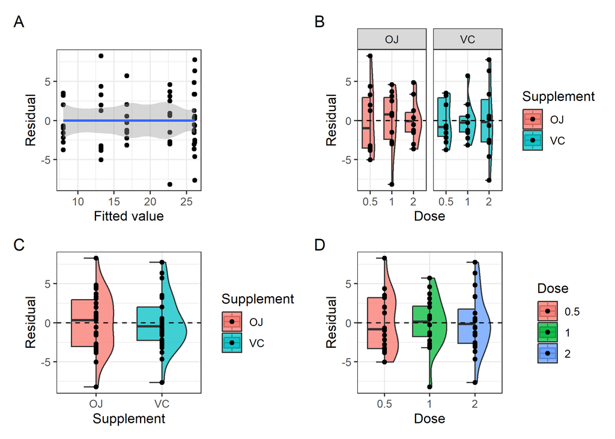

```r
# store residuals and fitted values alongside input data
df$resid = resid(pilot_mod)
df$fitted = fitted(pilot_mod)

r_v_f = ggplot(df, mapping=aes(x = fitted, y = resid))+
  geom_point()+
  geom_smooth(method = "loess")+
  theme_bw()+
  labs(x = "Fitted value", y = "Residual")

r_v_g = ggplot(df, mapping=aes(x = dose, y = resid, fill = supp))+
  geom_half_boxplot(side = "l", alpha = 0.75)+
  geom_half_violin(side = "r", alpha = 0.75)+
  geom_point()+
  geom_hline(yintercept = 0, linetype = 2)+
  theme_bw()+
  labs(x = "Dose", y = "Residual", fill = "Supplement")+
  facet_wrap(~supp)

r_v_supp = ggplot(df, mapping=aes(x = supp, y = resid, fill = supp))+
  geom_half_boxplot(side = "l", alpha = 0.75)+
  geom_half_violin(side = "r", alpha = 0.75)+
  geom_point()+
  geom_hline(yintercept = 0, linetype = 2)+
  theme_bw()+
  labs(x = "Supplement", y = "Residual", fill = "Supplement")

r_v_dose = ggplot(df, mapping=aes(x = dose, y = resid, fill = dose))+
  geom_half_boxplot(side = "l", alpha = 0.75)+
  geom_half_violin(side = "r", alpha = 0.75)+
  geom_point()+
  geom_hline(yintercept = 0, linetype = 2)+
  theme_bw()+
  labs(x = "Dose", y = "Residual", fill = "Dose")

r_design = "
AAABBB
AAABBB
CCCDDD
CCCDDD
"
r_v_f + r_v_g + r_v_supp + r_v_dose + plot_layout(design = r_design) + plot_annotation(tag_levels = "A")
```

## 1.4 Pairwise contrast significance testing via `emmeans`

When we looked at the model summary earlier, we did not discuss which model components we might want to conduct a power analysis on. The beta coefficients are one option, but here we discuss another option. Let’s say we are primarily interested in testing for significant differences in the means of treatment groups. As a reminder, herein a group is a particular combination of supplement and dose. For example, we might be interested in whether mean odontoblast length differs between OJ-0.5 and OJ-2, between OJ-0.5 and VC-0.5, OJ-0.5 and VC-2, and so on. There are 15 possible pairwise differences, or contrasts, that we could test. Let’s assume we are interested in all of them, and that together, the 15 pairwise contrasts constitute a family of tests.

One avenue forward is to use the `emmeans` package, which allows for the calculation of cell and/or marginal means for subgroups of the dataset. Let’s first estimate the cell means for each of the six treatment groups using the `emmeans()` function and the full set of predictors. Note that these are cell means because we are estimating the means at combinations of supplement and dose. Although it is beyond the scope of this tutorial, marginal means could also be obtained by estimating the mean of each supplement level averaged across all doses, or vice versa. The cell means are given below in the “emmean” column.

```r
# estimated group means (here, cell means)
pilot_mod_emmeans = emmeans::emmeans(pilot_mod, ~ supp * dose, data = df)
knitr::kable(pilot_mod_emmeans)
```

| supp | dose | emmean | SE | df | lower.CL | upper.CL |
| --- | --- | --- | --- | --- | --- | --- |
| OJ | 0.5 | 13.23 | 1.148353 | 54 | 10.927691 | 15.53231 |
| VC | 0.5 | 7.98 | 1.148353 | 54 | 5.677691 | 10.28231 |
| OJ | 1 | 22.70 | 1.148353 | 54 | 20.397691 | 25.00231 |
| VC | 1 | 16.77 | 1.148353 | 54 | 14.467691 | 19.07231 |
| OJ | 2 | 26.06 | 1.148353 | 54 | 23.757691 | 28.36231 |
| VC | 2 | 26.14 | 1.148353 | 54 | 23.837691 | 28.44231 |

These cell means provide the basis for pairwise contrasts, which are obtained using the `pairs()` function. The results of the 15 contrasts are given below, including the estimates for the mean differences as well as the associated P values. Note that these P values are Tukey-adjusted by default to control the family-wise error rate (FWER). The downstream power analysis will also use Tukey-adjusted P values because this matches the intended analysis that we’ve defined here. That is, we are interested in all pairwise contrasts, so power estimates should reflect the adjusted testing framework.

Note that some mean differences are quite small, such that reasonable sample sizes may never be well-powered. For example, the OJ dose2 - VC dose2 mean difference is the smallest of all contrasts at around 0.08 units. In comparison, the VC dose0.5 - VC dose2 contrast has the largest mean difference at 18.16 units. How this variation affects statistical power will be revisited later on. In summary, all 15 pairwise contrasts will be carried forward into the power analysis.

```r
# pairwise contrasts
pilot_mod_pairs = data.frame(pairs(pilot_mod_emmeans))
knitr::kable(pilot_mod_pairs[order(abs(pilot_mod_pairs$estimate)),])
```

|  | contrast | estimate | SE | df | t.ratio | p.value |
| --- | --- | --- | --- | --- | --- | --- |
| 15 | OJ dose2 - VC dose2 | -0.08 | 1.624016 | 54 | -0.0492606 | 1.0000000 |
| 11 | OJ dose1 - OJ dose2 | -3.36 | 1.624016 | 54 | -2.0689445 | 0.3187361 |
| 12 | OJ dose1 - VC dose2 | -3.44 | 1.624016 | 54 | -2.1182051 | 0.2936430 |
| 3 | OJ dose0.5 - VC dose1 | -3.54 | 1.624016 | 54 | -2.1797808 | 0.2640208 |
| 1 | OJ dose0.5 - VC dose0.5 | 5.25 | 1.624016 | 54 | 3.2327258 | 0.0242521 |
| 10 | OJ dose1 - VC dose1 | 5.93 | 1.624016 | 54 | 3.6514407 | 0.0073930 |
| 7 | VC dose0.5 - VC dose1 | -8.79 | 1.624016 | 54 | -5.4125065 | 0.0000210 |
| 13 | VC dose1 - OJ dose2 | -9.29 | 1.624016 | 54 | -5.7203852 | 0.0000069 |
| 14 | VC dose1 - VC dose2 | -9.37 | 1.624016 | 54 | -5.7696458 | 0.0000058 |
| 2 | OJ dose0.5 - OJ dose1 | -9.47 | 1.624016 | 54 | -5.8312215 | 0.0000046 |
| 4 | OJ dose0.5 - OJ dose2 | -12.83 | 1.624016 | 54 | -7.9001660 | 0.0000000 |
| 5 | OJ dose0.5 - VC dose2 | -12.91 | 1.624016 | 54 | -7.9494266 | 0.0000000 |
| 6 | VC dose0.5 - OJ dose1 | -14.72 | 1.624016 | 54 | -9.0639473 | 0.0000000 |
| 8 | VC dose0.5 - OJ dose2 | -18.08 | 1.624016 | 54 | -11.1328917 | 0.0000000 |
| 9 | VC dose0.5 - VC dose2 | -18.16 | 1.624016 | 54 | -11.1821523 | 0.0000000 |

```r
# specify which contrasts to include in power analysis
pilot_mod_contrast_list = pilot_mod_pairs$contrast
```

## 1.5 Data simulation functions

Having established the focus of our power analysis, let’s define some functions for simulating data. The first function below, **`sim_sampling()`**, constructs the matrix of predictor data by obtaining every combination of supplement and dose. This is accomplished using the `expand.grid()` function, which is useful for defining full-factorial or orthogonal predictor data. Note that the column “group” is included here as well for consistency with the observed pilot data. The grp_n argument specifies the number of replicate observations that should be simulated in each group, which provides the means for simulating data under an experimental design different from that of the pilot data. This tutorial will use the grp_n argument to characterize statistical power as a function of per-group sample size.

The second function, **`run_emmeans_sim()`**, is the core of the power analysis. Its arguments include the simulated predictor data (sim_data), the beta coefficients estimated from the linear model fitted using the pilot data (betas), the residual standard error estimated from the same linear model (sigma_val), the contrasts of interest (focal_contrasts), and the alpha for significance testing (alpha). This function first produces expected values (in this case, group means) using the simulated predictor data and the beta coefficients representing the predictor effects. Then, error is added to the expected values using random draws from a normal distribution of mean zero and standard deviation equal to the residual standard error. The resulting simulated response values (i.e., simulated odontoblast lengths) therefore match the structure of the data as captured by the linear model in a manner that enforces model assumptions. This latter point deserves some explanation. The pilot linear model assumed constant error variance (homoscedasticity), and this assumption is recapitulated in the simulation of random error, which is drawn from the same normal distribution for all observations. **By constructing simulated data in this manner, we assume that the parameters estimated using our pilot data and model are their true values.** Consequently, poor parameterization of the pilot linear model can compromise the utility of the downstream power analysis.

Next, we subject the simulated data to a statistical modeling process identical to the one we used for the observed pilot data. Here, we use `lm(len ~ supp * dose, data = sim_data)`, which estimates beta coefficients and residual variance from the simulated data. We pass the resulting model through `emmeans`-based pairwise contrast testing, and we check which P values are statistically significant at a desired alpha. Note again that `pairs()` produces Tukey-adjusted P values by default, and this is appropriate for the intended analysis that we’ve defined above. Researchers adapting this code to other problems should carefully consider whether their intended analysis framework matches the assumptions encoded here, particularly regarding the choice of multiple testing correction.

```r
# simulate sampling
sim_sampling = function(supp, dose, grp_n){
  sim_data = expand.grid(supp = supp,
                         dose = dose,
                         rep = 1:grp_n)

  # force data types to match a factor-dose model matrix structure
  sim_data$supp = as.factor(sim_data$supp)
  sim_data$dose = as.factor(sim_data$dose)
  sim_data$group = as.factor(paste0(sim_data$supp, "_", sim_data$dose))

  return(sim_data)
}

# simulate data and conduct significance testing
run_emmeans_sim = function(sim_data, betas, sigma_val, focal_contrasts, alpha = 0.05) {

  # generate the model matrix (the X matrix matching your formula)
  X = model.matrix(~ supp * dose, data = sim_data)

  # calculate expected group means (X * Beta)
  sim_data$expected_values = c(X %*% betas)

  # Generate random homoscedastic noise using your pilot sigma
  sim_data$noise = rnorm(nrow(sim_data), mean = 0, sd = sigma_val)

  # Inject the simulated response into your clean grid
  sim_data$len = sim_data$expected_values + sim_data$noise

  # Fit a clean model to the simulated data
  fit = lm(len ~ supp * dose, data = sim_data)

  # Estimate marginal means safely pointing to our unique matrix
  sim_pairs = emmeans::emmeans(fit, ~ supp * dose, data = sim_data)

  # pairs() applies Tukey HSD adjustment by default, controlling FWER across all
  # pairwise contrasts. This matches the intended analysis where all contrasts are
  # evaluated simultaneously, so power estimates reflect the adjusted testing framework.
  pvals = data.frame(pairs(sim_pairs)) %>% filter(contrast %in% focal_contrasts) %>% select(c(contrast, p.value))
  pvals$sig = pvals$p.value < alpha
  return(pvals)
}
```

## 1.6 Generating a single simulated dataset

Let’s manually simulate a single dataset using the processes encoded in the above functions to verify that simulated data roughly match the observed pilot data. We’ll call this simulated dataset “sim1_data”. We’ll also use a per-group sample size that matches the observed pilot data (i.e., 10 samples per group). We first use the `sim_sampling()` function to create predictor data with every combination of supplement and dose, each represented 10 times.

```r
# per-group sample size
sim1_grp_n = mean(table(df$group)) # note that per-group sample size is constant at 10 samples

# simulate predictor data
sim1_data = sim_sampling(supp = c("OJ", "VC"), dose = c(0.5, 1, 2), grp_n = sim1_grp_n)
knitr::kable(head(sim1_data, 15))
```

| supp | dose | rep | group |
| --- | --- | --- | --- |
| OJ | 0.5 | 1 | OJ_0.5 |
| VC | 0.5 | 1 | VC_0.5 |
| OJ | 1 | 1 | OJ_1 |
| VC | 1 | 1 | VC_1 |
| OJ | 2 | 1 | OJ_2 |
| VC | 2 | 1 | VC_2 |
| OJ | 0.5 | 2 | OJ_0.5 |
| VC | 0.5 | 2 | VC_0.5 |
| OJ | 1 | 2 | OJ_1 |
| VC | 1 | 2 | VC_1 |
| OJ | 2 | 2 | OJ_2 |
| VC | 2 | 2 | VC_2 |
| OJ | 0.5 | 3 | OJ_0.5 |
| VC | 0.5 | 3 | VC_0.5 |
| OJ | 1 | 3 | OJ_1 |

The next code chunk generates the simulated response values (i.e., odontoblast lengths). The column “expected values” contains the deterministic group means, the column “noise” contains the simulated random error, and the column “len” contains the simulated response values obtained by summing across the latter two columns. Let’s view the first 15 lines of the simulated dataset.

```r
# generate the model matrix (the X matrix matching your formula)
sim1_X = model.matrix(~ supp * dose, data = sim1_data)

# calculate expected group means (X * Beta)
sim1_data$expected_values = c(sim1_X %*% pilot_fixeff)

# Generate random homoscedastic noise using your pilot sigma
set.seed(1)
sim1_data$noise = rnorm(nrow(sim1_data), mean = 0, sd = pilot_sigma)

# Inject the simulated response into your clean grid
sim1_data$len = sim1_data$expected_values + sim1_data$noise

# identify that the data are simulated
sim1_data$dataset = "simulated_lm"
knitr::kable(head(sim1_data, 15))
```

| supp | dose | rep | group | expected_values | noise | len | dataset |
| --- | --- | --- | --- | --- | --- | --- | --- |
| OJ | 0.5 | 1 | OJ_0.5 | 13.23 | -2.2749115 | 10.9550885 | simulated_lm |
| VC | 0.5 | 1 | VC_0.5 | 7.98 | 0.6668844 | 8.6468844 | simulated_lm |
| OJ | 1 | 1 | OJ_1 | 22.70 | -3.0345112 | 19.6654888 | simulated_lm |
| VC | 1 | 1 | VC_1 | 16.77 | 5.7931208 | 22.5631208 | simulated_lm |
| OJ | 2 | 1 | OJ_2 | 26.06 | 1.1965783 | 27.2565783 | simulated_lm |
| VC | 2 | 1 | VC_2 | 26.14 | -2.9794582 | 23.1605418 | simulated_lm |
| OJ | 0.5 | 2 | OJ_0.5 | 13.23 | 1.7700554 | 15.0000554 | simulated_lm |
| VC | 0.5 | 2 | VC_0.5 | 7.98 | 2.6811607 | 10.6611607 | simulated_lm |
| OJ | 1 | 2 | OJ_1 | 22.70 | 2.0908989 | 24.7908989 | simulated_lm |
| VC | 1 | 2 | VC_1 | 16.77 | -1.1089908 | 15.6610092 | simulated_lm |
| OJ | 2 | 2 | OJ_2 | 26.06 | 5.4898992 | 31.5498992 | simulated_lm |
| VC | 2 | 2 | VC_2 | 26.14 | 1.4156811 | 27.5556811 | simulated_lm |
| OJ | 0.5 | 3 | OJ_0.5 | 13.23 | -2.2559801 | 10.9740199 | simulated_lm |
| VC | 0.5 | 3 | VC_0.5 | 7.98 | -8.0424862 | -0.0624862 | simulated_lm |
| OJ | 1 | 3 | OJ_1 | 22.70 | 4.0850869 | 26.7850869 | simulated_lm |

We next plot the simulated data alongside the observed pilot data. The simulation process indeed captures the structure of the dataset fairly well. There may be some minor deviation between the observed and simulated data, which may reflect the relatively small sample size. Researchers adapting this code to other problems should be wary of large discrepancies between observed pilot data and simulated data, which could indicate coding errors or a poorly parameterized pilot model.

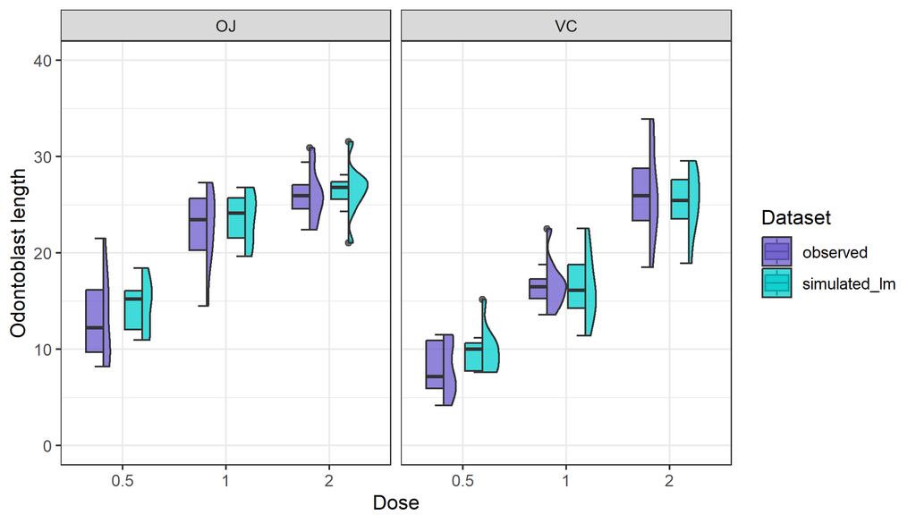

```r
# return to pilot data and identify that the data are observed [real]
df$dataset = "observed"

# merge pilot and simulated data
sim1_data_comp = dplyr::bind_rows(df, sim1_data)

# compare pilot and simulated data
ggplot(sim1_data_comp, mapping=aes(x = dose, y = len, fill = dataset))+
  geom_half_boxplot(side = "l", alpha = 0.75)+
  geom_half_violin(side = "r", alpha = 0.75)+
  scale_y_continuous(limits=c(0,40))+
    scale_fill_manual(values = c("observed" = "slateblue3", "simulated_lm" = "cyan3"))+
  theme_bw()+
  labs(x = "Dose", y = "Odontoblast length", fill = "Dataset")+
  facet_wrap(~supp)
```

Let’s also quickly test the `run_emmeans_sim()` function so that we are familiar with its outputs. Although the sim1_data dataset is used as input for this function, note that the response data are re-simulated and will not match the dataset generated above. The `run_emmeans_sim()` function reports the pairwise contrasts, their P values, and whether the contrasts are significant at a specified alpha (here, P < 0.05). For a single simulated dataset, a contrast is either significant (column sig == TRUE) or not (column sig == FALSE). Because we assume every contrast’s mean difference is truly non-zero, all contrasts would be significant in a perfect world. Accordingly, all sig == TRUE results are **true positives**. It follows that if we repeat this process many times, we can find the proportion of simulation replicates where sig == TRUE for a particular contrast; this proportion is therefore the proportion of positives detected as statistically significant (i.e., the **true positive rate**), which is also called **statistical power**. Statistical power is also interpretable as the probability of a true positive occurring. Repeating our simulation process many times and computing the true positive rate constitutes a **power analysis**.

```r
# demonstrate output of the run_emmeans_sim function
knitr::kable(head(
    run_emmeans_sim(sim_data = sim1_data,
                  betas = pilot_fixeff,
                  sigma_val = pilot_sigma,
                  focal_contrasts = pilot_mod_contrast_list,
                  alpha = 0.05),
    length(pilot_mod_contrast_list)
    )
  )
```

| contrast | p.value | sig |
| --- | --- | --- |
| OJ dose0.5 - VC dose0.5 | 0.0771117 | FALSE |
| OJ dose0.5 - OJ dose1 | 0.0000018 | TRUE |
| OJ dose0.5 - VC dose1 | 0.0188342 | TRUE |
| OJ dose0.5 - OJ dose2 | 0.0000000 | TRUE |
| OJ dose0.5 - VC dose2 | 0.0000000 | TRUE |
| VC dose0.5 - OJ dose1 | 0.0000000 | TRUE |
| VC dose0.5 - VC dose1 | 0.0000017 | TRUE |
| VC dose0.5 - OJ dose2 | 0.0000000 | TRUE |
| VC dose0.5 - VC dose2 | 0.0000000 | TRUE |
| OJ dose1 - VC dose1 | 0.0783921 | FALSE |
| OJ dose1 - OJ dose2 | 0.0063493 | TRUE |
| OJ dose1 - VC dose2 | 0.1696347 | FALSE |
| VC dose1 - OJ dose2 | 0.0000004 | TRUE |
| VC dose1 - VC dose2 | 0.0000476 | TRUE |
| OJ dose2 - VC dose2 | 0.7900422 | FALSE |

## 1.7 Power analysis via replicated simulation

Below, we’ll finally implement the replicated simulation. For this tutorial, I’ve specified n_sims = 1000 replicate simulations, which runs relatively fast when multiple cores are available for parallel computing and produces fairly stable results. Researchers should use a relatively large value for n_sims for production-quality power analyses used for decision-making (e.g., >= 1000 replicates). Another parameter, grp_n, controls the per-group sample sizes being simulated. Here, we vary this parameter in the range [10, 100] at an increment of five samples, which equates to a total dataset size in the range [60, 600] samples given that there are six treatment groups. 100 samples per group is rather large for an animal study, but we include it here to characterize power over a large range of dataset sizes. Viewing the first 20 lines of the raw results, we can see all 15 contrasts for the first simulation for a group size of 10 samples (i.e., column sim_id == 1). We can also see a portion of the second simulation with the same dataset parameters (sim_id == 2). Our raw output thus captures every contrast for every simulation replicate. To estimate power per contrast per group size, we must quantify the proportion of replicates where a given combination of contrast and group size is detected as statistically significant. We accomplish this in the next code chunk.

```r
# define power simulation parameters
n_sims = 1000 # number of replicate simulations
grp_n = seq(10, 100, 5) # per-group sample sizes

# detect available cores and use all but one to keep computer responsive
ncpus = max(c(1, parallel::detectCores() - 1))
cl = parallel::makeCluster(ncpus)
doParallel::registerDoParallel(cl)

# note that we are using doRNG to ensure reproducibility of the entire parallel process
set.seed(123)
t_start_lm = proc.time() # record start time
parallel_results = foreach(i = 1:length(grp_n),
                           .combine = rbind,
                           .packages = c("emmeans", "dplyr")) %dorng% {

                             # Generate experimental matrix for this row's setup
                             sim_data = sim_sampling(supp = c("OJ", "VC"),
                                                     dose = c(0.5, 1, 2),
                                                     grp_n = grp_n[i])

                             # Run the iterations
                             results = replicate(n = n_sims,
                                                 run_emmeans_sim(
                                                   sim_data = sim_data,
                                                   betas = pilot_fixeff,
                                                   sigma_val = pilot_sigma,
                                                   focal_contrasts = pilot_mod_contrast_list,
                                                   alpha = 0.05
                                                   ),
                                                 simplify = FALSE
                                                 )

                             results = dplyr::bind_rows(results, .id = "sim_id") |>
                               dplyr::mutate(grp_n = grp_n[i])
                           }
t_end_lm = proc.time() # record end time

parallel::stopCluster(cl)  # explicitly shut down the cluster

cat("lm simulation time elapsed:", (t_end_lm - t_start_lm)[3], "seconds.\n") # report simulation time
```

```
## lm simulation time elapsed: 201.5 seconds.
```

```r
knitr::kable(head(parallel_results, 20)) # view the raw results
```

| sim_id | contrast | p.value | sig | grp_n |
| --- | --- | --- | --- | --- |
| 1 | OJ dose0.5 - VC dose0.5 | 0.2279367 | FALSE | 10 |
| 1 | OJ dose0.5 - OJ dose1 | 0.0000001 | TRUE | 10 |
| 1 | OJ dose0.5 - VC dose1 | 0.1711134 | FALSE | 10 |
| 1 | OJ dose0.5 - OJ dose2 | 0.0000000 | TRUE | 10 |
| 1 | OJ dose0.5 - VC dose2 | 0.0000000 | TRUE | 10 |
| 1 | VC dose0.5 - OJ dose1 | 0.0000000 | TRUE | 10 |
| 1 | VC dose0.5 - VC dose1 | 0.0002819 | TRUE | 10 |
| 1 | VC dose0.5 - OJ dose2 | 0.0000000 | TRUE | 10 |
| 1 | VC dose0.5 - VC dose2 | 0.0000000 | TRUE | 10 |
| 1 | OJ dose1 - VC dose1 | 0.0003620 | TRUE | 10 |
| 1 | OJ dose1 - OJ dose2 | 0.3028687 | FALSE | 10 |
| 1 | OJ dose1 - VC dose2 | 0.7196829 | FALSE | 10 |
| 1 | VC dose1 - OJ dose2 | 0.0000002 | TRUE | 10 |
| 1 | VC dose1 - VC dose2 | 0.0000024 | TRUE | 10 |
| 1 | OJ dose2 - VC dose2 | 0.9825750 | FALSE | 10 |
| 2 | OJ dose0.5 - VC dose0.5 | 0.0000016 | TRUE | 10 |
| 2 | OJ dose0.5 - OJ dose1 | 0.0000012 | TRUE | 10 |
| 2 | OJ dose0.5 - VC dose1 | 0.1894718 | FALSE | 10 |
| 2 | OJ dose0.5 - OJ dose2 | 0.0000000 | TRUE | 10 |
| 2 | OJ dose0.5 - VC dose2 | 0.0000000 | TRUE | 10 |

The code below performs this aggregation and calculates power. Note that an observation where sig == TRUE is numerically encoded as a 1, such that the mean across replicates yields the proportion of observations where sig == TRUE. We also characterize the lower and upper bounds of the 95% confidence intervals (CIs) of the power estimates. These confidence intervals are useful in cases where computational limitations necessitate small values of n_sims (e.g., << 100). For example, researchers could optimize experimental design by selecting the group size where the lower 95% CI of power for a contrast exceeds some threshold (often power >= 0.80 or 80%). When many replicate simulations are performed, the CIs will be very narrow such that the lower 95% CI may be negligibly smaller than the point estimate, and the utility of the CI decreases.

```r
power_df = parallel_results %>%
  group_by(contrast, grp_n) %>%
  summarise(power = mean(sig, na.rm = TRUE),
            power_ci95_low = binom.test(x=sum(as.numeric(sig)==1), n=n())$conf.int[1],
            power_ci95_high = binom.test(x=sum(as.numeric(sig)==1), n=n())$conf.int[2])
kable(head(power_df))
```

| contrast | grp_n | power | power_ci95_low | power_ci95_high |
| --- | --- | --- | --- | --- |
| OJ dose0.5 - OJ dose1 | 10 | 0.998 | 0.9927942 | 0.9997577 |
| OJ dose0.5 - OJ dose1 | 15 | 1.000 | 0.9963179 | 1.0000000 |
| OJ dose0.5 - OJ dose1 | 20 | 1.000 | 0.9963179 | 1.0000000 |
| OJ dose0.5 - OJ dose1 | 25 | 1.000 | 0.9963179 | 1.0000000 |
| OJ dose0.5 - OJ dose1 | 30 | 1.000 | 0.9963179 | 1.0000000 |
| OJ dose0.5 - OJ dose1 | 35 | 1.000 | 0.9963179 | 1.0000000 |

Let’s plot power as a function of the contrast and the per-group sample size. We’ll highlight a target power, which is a minimum power that we would like to meet or exceed. A common target power is 0.80 or 80%, which we’ll use here and indicate with a red horizontal dashed line. Recall that this means a given experimental design detects a given, truly non-zero contrast as statistically significant with 80% probability. We can see that power varies among contrasts but increases with per-group sample size, which is expected behavior. Power is expected to vary among contrasts because there is variation in the magnitude of differences in means among groups. Smaller mean differences require more data to detect as statistically significant than larger mean differences.

The plots also indicate the per-group sample size of the pilot data with a black vertical dashed line at x = 10 samples per group. We can see that our pilot experiment was under-powered to detect some contrasts as statistically significant. For example, the OJ dose0.5 - VC dose0.5 contrast has power < 80% for the pilot dataset’s per-group sample size; increasing the per-group sample size to 15 in a follow-up experiment would provide power >= 80% to detect this contrast as significant, provided the pilot model’s parameter estimates are true.

In other cases, power is uniformly far below our target of 80% across the range of per-group sample sizes that we simulated. For example, check the power curve for the OJ dose2 - VC dose2 contrast. We expected this given that the mean difference estimated from the pilot data is the smallest of all contrasts at around 0.08 units. In comparison, the largest mean difference estimated from the pilot data is 18.16 units (VC dose0.5 - VC dose2 contrast), and this contrast is well-powered even at small sample sizes. Although we assumed the mean difference is truly 0.08 units for the OJ dose2 - VC dose2 contrast, we might consider this value negligibly different from 0 and choose to ignore this contrast when optimizing the design of a follow-up experiment.

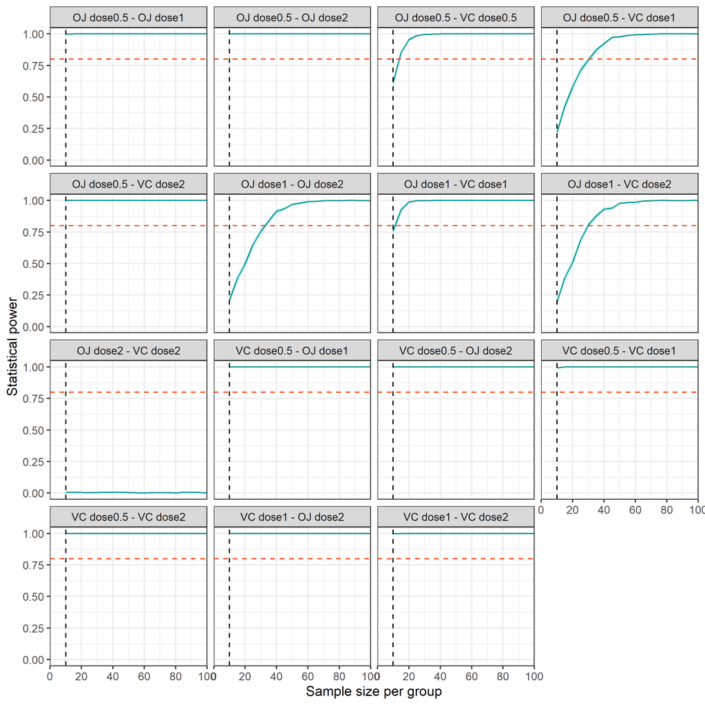

```r
# power that should be achieved or surpassed
target_power = 0.80

# plot power curves
lm_power_curves = ggplot(power_df, mapping=aes(x=grp_n, y=power, group=contrast))+
  geom_line(colour = "cyan4")+
  geom_ribbon(mapping=aes(x=grp_n, ymin=power_ci95_low, ymax=power_ci95_high), alpha=0.20, fill = "cyan3")+
  scale_x_continuous(limits=c(0, NA), breaks=seq(0, max(grp_n), 20), expand=c(0,0))+
  facet_wrap(~contrast)+
  theme_bw()+
  geom_hline(yintercept=target_power, colour="orangered", linetype=2)+
  geom_vline(xintercept=mean(table(df$group)), colour="black", linetype=2)+
  labs(x="Sample size per group", y="Statistical power")
lm_power_curves
```

To inform the design of a follow-up experiment, let’s identify the minimum per-group sample size required to achieve power >= 80% for each contrast. Note once again that we are using the lower 95% CI of power, which will err on the side of suggesting a larger group size than the point estimate, particularly when few simulation replicates are performed (i.e., n_sims << 100). The OJ dose2 - VC dose2 contrast never achieves the target power and thus has a minimum group size recommendation of NA.

```r
# determine minimum sample size per contrast
lm_power_design_per_contrast = power_df %>%
  group_by(contrast) %>%
  summarise(min_group_size_target_power = grp_n[min(which(power_ci95_low >= target_power))])

knitr::kable(lm_power_design_per_contrast, caption = "Minimum group size for power >= 80% per contrast (lm)")
```

Minimum group size for power >= 80% per contrast (lm)

| contrast | min_group_size_target_power |
| --- | --- |
| OJ dose0.5 - OJ dose1 | 10 |
| OJ dose0.5 - OJ dose2 | 10 |
| OJ dose0.5 - VC dose0.5 | 15 |
| OJ dose0.5 - VC dose1 | 35 |
| OJ dose0.5 - VC dose2 | 10 |
| OJ dose1 - OJ dose2 | 35 |
| OJ dose1 - VC dose1 | 15 |
| OJ dose1 - VC dose2 | 35 |
| OJ dose2 - VC dose2 | NA |
| VC dose0.5 - OJ dose1 | 10 |
| VC dose0.5 - OJ dose2 | 10 |
| VC dose0.5 - VC dose1 | 10 |
| VC dose0.5 - VC dose2 | 10 |
| VC dose1 - OJ dose2 | 10 |
| VC dose1 - VC dose2 | 10 |

Approaching this problem another way, we can ask what minimum per-group sample size is necessary to achieve the target power for 14 of the 15 contrasts, thereby accommodating the fact that no reasonable sample size will provide high power to detect the OJ dose2 - VC dose2 contrast as significant. For n_sims = 1000 replicate simulations, the answer is a per-group sample size of 35, which is equivalent to a total dataset size of 210 samples. One simplification we’ve made here is that group sizes must be uniform, which is consistent with the common goal of producing a balanced dataset.

```r
# determine minimum sample size
## where the lower boundary of the power 95% CI > target_power for all but one contrast
lm_power_design_selection = power_df %>%
  group_by(grp_n) %>%
  summarise(n_contrasts = length(unique(contrast)),
            n_contrasts_target_power = sum(power_ci95_low >= target_power
            )
  ) %>%
  filter(n_contrasts - n_contrasts_target_power <= 1) %>%
  arrange(grp_n)

knitr::kable(lm_power_design_selection[1,], caption = "Minimum group size for power >= 80% in 14 of 15 contrasts (lm)")
```

Minimum group size for power >= 80% in 14 of 15 contrasts (lm)

| grp_n | n_contrasts | n_contrasts_target_power |
| --- | --- | --- |
| 35 | 15 | 14 |

# Part 2: Power analysis accounting for heteroscedasticity via `nlme::gls()`

In the previous section, we implemented a power analysis for a relatively simple scenario where a simple linear model captured our dataset reasonably well. This will often not be the case, and we may need to fit a more complicated model to our pilot data and subsequently simulate data from that more complex model to perform a power analysis.

Let’s revisit the assumption of constant error variance or homoscedasticity. The Bartlett test conducted earlier returned a non-significant result, suggesting no strong evidence against homoscedasticity in the pilot data. However, with only 10 observations per group, the test itself has limited power to detect heteroscedasticity even if it is present. As a robustness check, we will re-implement the power analysis using a generalized least squares (GLS) model that explicitly estimates group-specific residual variances, rather than assuming a single pooled variance across all groups.

This can be accomplished using the `nlme::gls()` function with a `varIdent()` variance structure, which allows each group to have its own residual standard error. If the resulting power curves are similar to those produced by the homoscedastic `lm()`-based analysis, we can be more confident that the original power conclusions are robust to the homoscedasticity assumption. If they diverge meaningfully for specific contrasts, the `gls()`-based estimates should be preferred.

Beyond this specific application, nlme can accommodate effectively arbitrarily complex variance and correlation structures, and this section is intended as a springboard for researchers working with experimental designs that involve more complex data-generating processes than the one considered here.

## 2.1 Creating an initial generalized least squares (GLS) model accounting for heteroscedasticity

The code chunk below fits a GLS model with a `varIdent()` variance structure. We can once again access the beta coefficients using the `coef()` function.

```r
# pilot model using gls
pilot_gls = nlme::gls(
  model = len ~ supp * dose,
  weights = nlme::varIdent(form = ~ 1 | group),
  data = df
)
summary(pilot_gls)
```

```
## Generalized least squares fit by REML
##   Model: len ~ supp * dose
##   Data: df
##        AIC      BIC    logLik
##   323.1133 346.9811 -149.5566
##
## Variance function:
##  Structure: Different standard deviations per stratum
##  Formula: ~1 | group
##  Parameter estimates:
##    VC_0.5      VC_1      VC_2    OJ_0.5      OJ_1      OJ_2
## 1.0000000 0.9157915 1.7468021 1.6237043 1.4239198 0.9666744
##
## Coefficients:
##              Value Std.Error   t-value p-value
## (Intercept)  13.23  1.410273  9.381160  0.0000
## suppVC       -5.25  1.656278 -3.169759  0.0025
## dose1         9.47  1.875746  5.048659  0.0000
## dose2        12.83  1.641284  7.817051  0.0000
## suppVC:dose1 -0.68  2.214834 -0.307021  0.7600
## suppVC:dose2  5.33  2.397929  2.222751  0.0304
##
##  Correlation:
##              (Intr) suppVC dose1  dose2  spVC:1
## suppVC       -0.851
## dose1        -0.752  0.640
## dose2        -0.859  0.732  0.646
## suppVC:dose1  0.637 -0.748 -0.847 -0.547
## suppVC:dose2  0.588 -0.691 -0.442 -0.684  0.517
##
## Standardized residuals:
##        Min         Q1        Med         Q3        Max
## -2.0966792 -0.7349703 -0.1073423  0.7337911  2.2780417
##
## Residual standard error: 2.746606
## Degrees of freedom: 60 total; 54 residual
```

```r
# obtain fixed effects
pilot_gls_fixeff = coef(pilot_gls)
```

Obtaining the residual standard error is more complex than it was for the simple linear model fitted in Part 1. Specifically, the model stores a base residual standard error (sigma), which is modified by group-specific weights via multiplication. The reference group is given a weight of 1.0 and omitted by default. Below, we add the reference group back in and calculate the group-specific residual standard errors by multiplying base residual standard error by the the group weights. We can see that the groups OJ_0.5 and VC_2 have the highest residual standard errors (~ 4.46 and 4.80, respectively), which is consistent with our observation from the exploratory analysis at the start of Part 1.

```r
###
# obtain base sigma
pilot_sigma_gls_base = sigma(pilot_gls)

# obtain group weights stored in model
pilot_sigma_gls_group_weights = coef(pilot_gls$modelStruct$varStruct, unconstrained = FALSE)

# determine reference group and specify weight of 1
## also evident in summary(pilot_gls)
ref_group = setdiff(unique(df$group), names(pilot_sigma_gls_group_weights))
pilot_sigma_gls_all_weights = c(setNames(1.0, ref_group), pilot_sigma_gls_group_weights)

# use base sigma and group weights to calculate group sigmas
pilot_sigma_gls = c(pilot_sigma_gls_all_weights * pilot_sigma_gls_base)

# view sigma components
knitr::kable(data.frame(base_sigma = pilot_sigma_gls_base), caption = "Base sigma")
```

Base sigma

| base_sigma |
| --- |
| 2.746606 |

```r
knitr::kable(t(pilot_sigma_gls_group_weights), caption = "Group weights")
```

Group weights

| VC_1 | VC_2 | OJ_0.5 | OJ_1 | OJ_2 |
| --- | --- | --- | --- | --- |
| 0.9157915 | 1.746802 | 1.623704 | 1.42392 | 0.9666744 |

```r
knitr::kable(t(pilot_sigma_gls_all_weights), caption = "Group weights with reference group added")
```

Group weights with reference group added

| VC_0.5 | VC_1 | VC_2 | OJ_0.5 | OJ_1 | OJ_2 |
| --- | --- | --- | --- | --- | --- |
| 1 | 0.9157915 | 1.746802 | 1.623704 | 1.42392 | 0.9666744 |

```r
knitr::kable(t(pilot_sigma_gls), caption = "Group residual standard errors")
```

Group residual standard errors

| VC_0.5 | VC_1 | VC_2 | OJ_0.5 | OJ_1 | OJ_2 |
| --- | --- | --- | --- | --- | --- |
| 2.746606 | 2.515318 | 4.797777 | 4.459676 | 3.910946 | 2.655074 |

## 2.2 Pairwise contrast significance testing via `emmeans`

In Part 1, we used functions from the `emmeans` package to test pairwise contrasts based on the pilot simple linear model. We can apply the same functions to the pilot GLS model. We do so below, and all 15 pairwise contrasts will be carried forward into the power analysis as before.

```r
# estimated group means (here, cell means)
pilot_gls_emmeans = emmeans::emmeans(pilot_gls, ~ supp * dose, data = df)
knitr::kable(pilot_gls_emmeans)
```

| supp | dose | emmean | SE | df | lower.CL | upper.CL |
| --- | --- | --- | --- | --- | --- | --- |
| OJ | 0.5 | 13.23 | 1.4102734 | 9.003139 | 10.03991 | 16.42009 |
| VC | 0.5 | 7.98 | 0.8685531 | 9.366054 | 6.02684 | 9.93316 |
| OJ | 1 | 22.70 | 1.2367499 | 9.007156 | 19.90262 | 25.49738 |
| VC | 1 | 16.77 | 0.7954135 | 9.013204 | 14.97105 | 18.56895 |
| OJ | 2 | 26.06 | 0.8396080 | 8.986468 | 24.16024 | 27.95976 |
| VC | 2 | 26.14 | 1.5171903 | 8.997622 | 22.70774 | 29.57226 |

```r
# pairwise contrasts
pilot_gls_pairs = data.frame(pairs(pilot_gls_emmeans))
knitr::kable(pilot_gls_pairs)
```

| contrast | estimate | SE | df | t.ratio | p.value |
| --- | --- | --- | --- | --- | --- |
| OJ dose0.5 - VC dose0.5 | 5.25 | 1.656278 | 15.06356 | 3.1697586 | 0.0576676 |
| OJ dose0.5 - OJ dose1 | -9.47 | 1.875746 | 17.70121 | -5.0486593 | 0.0010509 |
| OJ dose0.5 - VC dose1 | -3.54 | 1.619121 | 14.19815 | -2.1863712 | 0.3016470 |
| OJ dose0.5 - OJ dose2 | -12.83 | 1.641284 | 14.66217 | -7.8170513 | 0.0000164 |
| OJ dose0.5 - VC dose2 | -12.91 | 2.071410 | 17.90784 | -6.2324711 | 0.0000910 |
| VC dose0.5 - OJ dose1 | -14.72 | 1.511269 | 16.21932 | -9.7401574 | 0.0000005 |
| VC dose0.5 - VC dose1 | -8.79 | 1.177738 | 18.11815 | -7.4634589 | 0.0000081 |
| VC dose0.5 - OJ dose2 | -18.08 | 1.208026 | 18.00754 | -14.9665690 | 0.0000000 |
| VC dose0.5 - VC dose2 | -18.16 | 1.748214 | 14.31696 | -10.3877464 | 0.0000006 |
| OJ dose1 - VC dose1 | 5.93 | 1.470453 | 15.35544 | 4.0327701 | 0.0109350 |
| OJ dose1 - OJ dose2 | -3.36 | 1.494822 | 15.90674 | -2.2477597 | 0.2705449 |
| OJ dose1 - VC dose2 | -3.44 | 1.957401 | 17.30594 | -1.7574329 | 0.5154558 |
| VC dose1 - OJ dose2 | -9.29 | 1.156557 | 18.11727 | -8.0324612 | 0.0000029 |
| VC dose1 - VC dose2 | -9.37 | 1.713053 | 13.60315 | -5.4697679 | 0.0010299 |
| OJ dose2 - VC dose2 | -0.08 | 1.734015 | 14.08215 | -0.0461357 | 1.0000000 |

```r
# specify which contrasts to include in power analysis
pilot_gls_contrast_list = pilot_gls_pairs$contrast
```

## 2.3 A new simulation function accounting for heteroscedasticity

In Part 1, we defined two functions: `sim_sampling()` and `run_emmeans_sim()`. The `sim_sampling()` function can be re-used directly since it simply constructs the matrix of predictor data by obtaining every combination of supplement and dose.

However, `run_emmeans_sim()` enforced an assumption of homoscedasticity, which we have explicitly discarded in favor of a more complex model that permits variation in residual standard error among groups. Below, we write a new function, **`run_emmeans_sim_gls()`**, to accommodate this complexity.

As before, its arguments include the simulated predictor data (sim_data), the beta coefficients estimated from the linear model fitted using the pilot data (betas), the contrasts of interest (focal_contrasts), and the alpha for significance testing (alpha). The only new argument is sigma_lookup, which replaces the sigma_val argument that supplies a single estimate for the residual standard error. Sigma_lookup uses the named vector of per-group residual standard errors to draw random error from a different normal distribution for each group.

We then subject the simulated data to a `gls()`-based statistical modeling process identical to the one we used for the observed pilot data. We pass the resulting model through `emmeans`-based pairwise contrast testing, and we check which P values are statistically significant at a desired alpha. Note again that `pairs()` produces Tukey-adjusted P values by default, and this is appropriate for the intended analysis that we’ve defined above (i.e., performing all pairwise contrasts as a family of tests). Note that run-time may be substantially longer due to the additional computation associated with the flexible variance structure.

```r
# simulate data and conduct significance testing
run_emmeans_sim_gls = function(sim_data, betas, sigma_lookup, focal_contrasts, alpha = 0.05) {

  # generate the model matrix (the X matrix matching your formula)
  X = model.matrix(~ supp * dose, data = sim_data)

  # calculate expected group means (X * Beta)
  sim_data$expected_values = c(X %*% betas)

  # Generate random heteroskedastic noise using group sigmas from pilot gls model
  sim_data$noise = NA
  for (i in names(sigma_lookup)){
    sim_data$noise[sim_data$group == i] = rnorm(sum(sim_data$group == i), mean = 0, sd = sigma_lookup[i])
  }

  # Inject the simulated response into your clean grid
  sim_data$len = sim_data$expected_values + sim_data$noise

  # wrap gls fit in tryCatch to handle convergence failures
  fit = tryCatch(
    nlme::gls(model = len ~ supp * dose,
              weights = nlme::varIdent(form = ~ 1 | group),
              data = sim_data),
    error = function(e) NULL
  )

  # return NA for all contrasts if model failed to converge
  if (is.null(fit)) {
    pvals = data.frame(contrast = focal_contrasts, p.value = NA, sig = NA)
    return(pvals)
  }

  # Estimate marginal means safely pointing to our unique matrix
  sim_pairs = emmeans::emmeans(fit, ~ supp * dose, data = sim_data)

  # pairs() applies Tukey HSD adjustment by default, controlling FWER across all
  # pairwise contrasts. This matches the intended analysis where all contrasts are
  # evaluated simultaneously, so power estimates reflect the adjusted testing framework.
  pvals = data.frame(pairs(sim_pairs)) %>% filter(contrast %in% focal_contrasts) %>% select(c(contrast, p.value))
  pvals$sig = pvals$p.value < alpha
  return(pvals)
}
```

## 2.4 Generating a single simulated dataset via the new function

As in Part 1, let’s manually simulate a single dataset using the processes encoded in the `run_emmeans_sim_gls()` function to verify that simulated data roughly match the observed pilot data. We’ll call this simulated dataset “sim2_data”. We’ll again use a per-group sample size that matches the observed pilot data (i.e., 10 samples per group). For comparison, we’ll also include the lm-based simulated data generated in Part 1 (sim1_data).

We see that the `gls()`-based simulation indeed captures the structure of the dataset fairly well, but the improvement over the data simulated using the lm-based method in Part 1 is insubstantial. The new simulated data may match the group variances slightly better, although it is difficult to tell with just a single simulated dataset from each method. The insubstantial difference is consistent with the non-significant Bartlett test, which suggests that there is insubstantial heteroscedasticity, if any. Thus, both the `lm()`- and `gls()`-based models should fit similarly well.

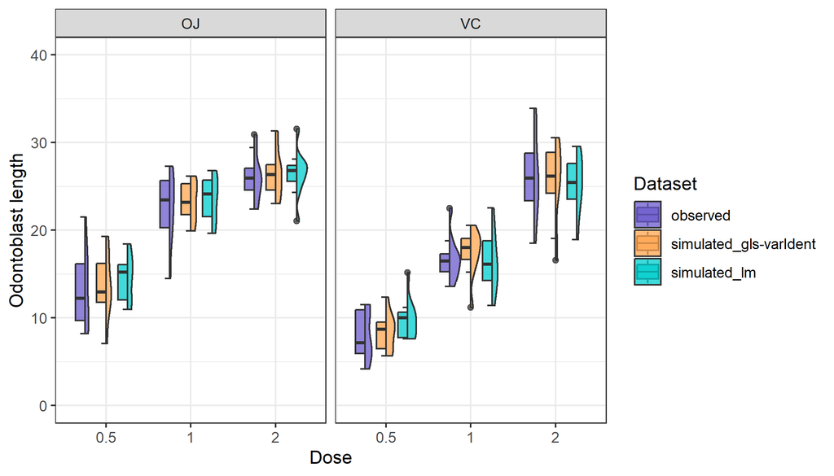

```r
sim2_grp_n = sim1_grp_n # use same parameters as above
sim2_data = sim_sampling(supp = c("OJ", "VC"), dose = c(0.5, 1, 2), grp_n = sim2_grp_n)

# generate the model matrix (the X matrix matching your formula)
sim2_X = model.matrix(~ supp * dose, data = sim2_data)

# calculate expected group means (X * Beta)
sim2_data$expected_values = c(sim2_X %*% pilot_gls_fixeff)

# Generate random heteroskedastic noise using group sigmas from pilot gls model
sim2_data$noise = NA
set.seed(1)
for (i in names(pilot_sigma_gls)){
  sim2_data$noise[sim2_data$group == i] = rnorm(sum(sim2_data$group == i), mean = 0, sd = pilot_sigma_gls[i])
}

# calculate the simulated response as the sum of the expected values and noise
sim2_data$len = sim2_data$expected_values + sim2_data$noise

# identify that the data are simulated
sim2_data$dataset = "simulated_gls-varIdent"

# merge pilot and simulated data
sim2_data_comp = dplyr::bind_rows(
  df,
  sim1_data %>% select(supp, dose, group, len, dataset),
  sim2_data %>% select(supp, dose, group, len, dataset)
)

# compare pilot and simulated data
ggplot(sim2_data_comp, mapping=aes(x = dose, y = len, fill = dataset))+
  geom_half_boxplot(side = "l", alpha = 0.75)+
  geom_half_violin(side = "r", alpha = 0.75)+
  scale_y_continuous(limits=c(0,40))+
  scale_fill_manual(values = c("observed" = "slateblue3", "simulated_gls-varIdent" = "tan1", "simulated_lm" = "cyan3"))+
  theme_bw()+
  labs(x = "Dose", y = "Odontoblast length", fill = "Dataset")+
  facet_wrap(~supp)
```

## 2.5 Power analysis via replicated simulation

Note that `nlme::gls()` with a `varIdent()` variance structure may fail to converge for some simulated datasets. Affected replicates are excluded from power calculations via `na.rm = TRUE`, which reduces the effective number of replicates contributing to the power estimate at those group sizes. The table below reports the convergence failure rate per group size.

```r
# detect available cores and use all but one to keep computer responsive
ncpus = max(c(1, parallel::detectCores() - 1))
cl = parallel::makeCluster(ncpus)
doParallel::registerDoParallel(cl)

# note that we are using doRNG to ensure reproducibility of the entire parallel process
set.seed(123)
t_start_gls = proc.time() # record start time
gls_parallel_results = foreach(i = 1:length(grp_n),
                           .combine = rbind,
                           .packages = c("nlme", "emmeans", "dplyr")) %dorng% {

                             # Generate experimental matrix for this row's setup
                             sim_data = sim_sampling(supp = c("OJ", "VC"),
                                                     dose = c(0.5, 1, 2),
                                                     grp_n = grp_n[i])

                             # Run the iterations
                             results = replicate(n = n_sims,
                                                 run_emmeans_sim_gls(
                                                   sim_data = sim_data,
                                                   betas = pilot_gls_fixeff,
                                                   sigma_lookup = pilot_sigma_gls,
                                                   focal_contrasts = pilot_gls_contrast_list,
                                                   alpha = 0.05
                                                 ),
                                                 simplify = FALSE
                             )

                             results = dplyr::bind_rows(results, .id = "sim_id") |>
                               dplyr::mutate(grp_n = grp_n[i])
                           }
t_end_gls = proc.time() # record end time

parallel::stopCluster(cl)  # explicitly shut down the cluster

# compute power
gls_power_df = gls_parallel_results %>%
  group_by(contrast, grp_n) %>%
  summarise(power = mean(sig, na.rm = TRUE),
            power_ci95_low = binom.test(x=sum(as.numeric(sig)==1, na.rm = TRUE), n=sum(!is.na(sig)))$conf.int[1],
            power_ci95_high = binom.test(x=sum(as.numeric(sig)==1, na.rm = TRUE), n=sum(!is.na(sig)))$conf.int[2])

cat("GLS simulation time elapsed:", (t_end_gls - t_start_gls)[3], "seconds.\n") # report simulation time
```

```
## GLS simulation time elapsed: 301.43 seconds.
```

```r
# report convergence failure rate per group size
gls_parallel_results %>%
  group_by(grp_n) %>%
  summarise(n_sims_total = n_distinct(sim_id),
            n_sims_failed = n_distinct(sim_id[is.na(sig)]),
            pct_failed = round(100 * n_sims_failed / n_sims_total, 1)) %>%
  knitr::kable(caption = "GLS convergence failure rate by group size (% of simulation replicates)")
```

GLS convergence failure rate by group size (% of simulation replicates)

| grp_n | n_sims_total | n_sims_failed | pct_failed |
| --- | --- | --- | --- |
| 10 | 1000 | 0 | 0.0 |
| 15 | 1000 | 0 | 0.0 |
| 20 | 1000 | 0 | 0.0 |
| 25 | 1000 | 0 | 0.0 |
| 30 | 1000 | 0 | 0.0 |
| 35 | 1000 | 0 | 0.0 |
| 40 | 1000 | 0 | 0.0 |
| 45 | 1000 | 0 | 0.0 |
| 50 | 1000 | 0 | 0.0 |
| 55 | 1000 | 0 | 0.0 |
| 60 | 1000 | 0 | 0.0 |
| 65 | 1000 | 0 | 0.0 |
| 70 | 1000 | 0 | 0.0 |
| 75 | 1000 | 0 | 0.0 |
| 80 | 1000 | 0 | 0.0 |
| 85 | 1000 | 0 | 0.0 |
| 90 | 1000 | 0 | 0.0 |
| 95 | 1000 | 0 | 0.0 |
| 100 | 1000 | 2 | 0.2 |

## 2.6 Comparing the `gls()`-based approach with the `lm()`-based approach.

The objective of Part 2 is to compare our initial power analysis with a power analysis based on a more complex model that may better capture qualities of the dataset. The code chunk below compares power curves for the two approaches.

The two approaches yield similar results for most contrasts, with a notable exception being the OJ dose1 - VC dose2 contrast. The power curve for this contrast is shifted lower under the `gls()`-based approach relative to the `lm()`-based approach. This contrast involves two groups, OJ dose1 and VC dose2, whose per-group residual standard errors estimated by the GLS model (3.91 and 4.80, respectively) both exceed the pooled residual standard error estimated by the simple linear model (3.63). The `gls()`-based power estimate is therefore more conservative for this contrast because it correctly accounts for the elevated variance in these specific groups, rather than borrowing precision from lower-variance groups via pooling. This suggests the `lm()`-based power estimate is optimistic for this contrast, and the `gls()`-based estimate should be preferred.

Note that the `lm()`-based and `gls()`-based approaches differ in both their variance structure and estimation method: `lm()` uses ordinary least squares (OLS) while `nlme::gls()` uses restricted maximum likelihood (REML). Accordingly, observed differences in power curves cannot be attributed solely to the heteroscedasticity modeling. However, for balanced designs as in the ToothGrowth dataset, OLS and REML produce very similar fixed effect estimates, and the variance structure is expected to be the dominant source of any differences observed here. We could have used GLS without the varIdent variance structure in Part 1, but Part 1 intentionally concerns `lm()` because it is a common entry point for researchers.

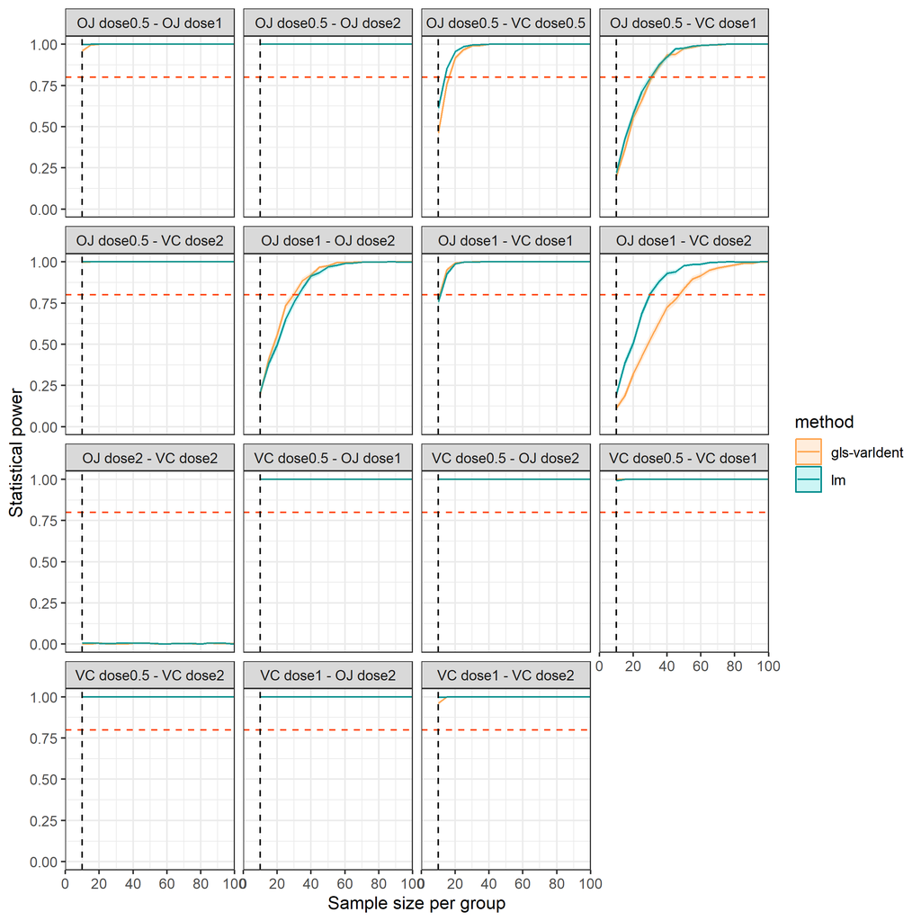

```r
# combine power curve data
power_df$method = "lm"
gls_power_df$method = "gls-varIdent"
combined_power_df = dplyr::bind_rows(power_df, gls_power_df)

# plot combined power curves
ggplot(combined_power_df, mapping=aes(x=grp_n, y=power, colour=method, fill=method, group=interaction(contrast,method)))+
  geom_line()+
  geom_ribbon(mapping=aes(x=grp_n, ymin=power_ci95_low, ymax=power_ci95_high, fill=method, colour=NULL), alpha=0.20)+
  scale_x_continuous(limits=c(0, NA), breaks=seq(0, max(grp_n), 20), expand=c(0,0))+
  scale_colour_manual(values = c("gls-varIdent" = "tan1", "lm" = "cyan4"))+
  scale_fill_manual(values = c("gls-varIdent" = "tan1", "lm" = "cyan3"))+
  facet_wrap(~contrast)+
  theme_bw()+
  geom_hline(yintercept=0.80, colour="orangered", linetype=2)+
  geom_vline(xintercept=10, colour="black", linetype=2)+
  labs(x="Sample size per group", y="Statistical power")
```

We can also compare the minimum group size necessary for each contrast to achieve some target power (here, 80%). The table below gives the contrast, the minimum group size for power >= 80% using the `gls()`-based approach, the minimum group size for power >= 80% using the `lm()`-based approach, and the difference between the two minimum group sizes. Positive differences indicate that the `gls()`-based approach suggests larger per-group sample sizes are necessary to achieve the target power than suggested by the `lm()`-based approach and vice versa. We can see that the two approaches show only minor differences except for the contrast highlighted previously, where the `gls()`-based approach suggests substantially more samples are needed to achieve high power than suggested by the `lm()`-based approach; the discrepancy amounts to an additional 15 samples per group under the `gls()`-based approach.

```r
###
# determine minimum sample size per contrast for target power gls
gls_power_design_per_contrast = gls_power_df %>%
  group_by(contrast) %>%
  summarise(gls_min_group_size_target_power = grp_n[min(which(power_ci95_low >= target_power))])

# merge with lm-based results
comp_power_design_per_contrast = merge.data.frame(x = gls_power_design_per_contrast,
                                                 y = lm_power_design_per_contrast,
                                                 by = "contrast")
colnames(comp_power_design_per_contrast)[3] = paste0("lm_", colnames(comp_power_design_per_contrast)[3])

# calculate difference in minimum sample size per contrast for target power
comp_power_design_per_contrast$min_group_size_diff = comp_power_design_per_contrast$gls_min_group_size_target_power - comp_power_design_per_contrast$lm_min_group_size_target_power

knitr::kable(comp_power_design_per_contrast, caption = "Minimum group size for power >= 80% per contrast (`gls` versus `lm`)")
```

Minimum group size for power >= 80% per contrast (`gls` versus `lm`)

| contrast | gls_min_group_size_target_power | lm_min_group_size_target_power | min_group_size_diff |
| --- | --- | --- | --- |
| OJ dose0.5 - OJ dose1 | 10 | 10 | 0 |
| OJ dose0.5 - OJ dose2 | 10 | 10 | 0 |
| OJ dose0.5 - VC dose0.5 | 20 | 15 | 5 |
| OJ dose0.5 - VC dose1 | 35 | 35 | 0 |
| OJ dose0.5 - VC dose2 | 10 | 10 | 0 |
| OJ dose1 - OJ dose2 | 35 | 35 | 0 |
| OJ dose1 - VC dose1 | 15 | 15 | 0 |
| OJ dose1 - VC dose2 | 50 | 35 | 15 |
| OJ dose2 - VC dose2 | NA | NA | NA |
| VC dose0.5 - OJ dose1 | 10 | 10 | 0 |
| VC dose0.5 - OJ dose2 | 10 | 10 | 0 |
| VC dose0.5 - VC dose1 | 10 | 10 | 0 |
| VC dose0.5 - VC dose2 | 10 | 10 | 0 |
| VC dose1 - OJ dose2 | 10 | 10 | 0 |
| VC dose1 - VC dose2 | 10 | 10 | 0 |

As in Part 1, we can also ask what minimum per-group sample size is necessary to achieve the target power for 14 of the 15 contrasts, thereby accommodating the fact that no reasonable sample size will provide high power to detect the OJ dose2 - VC dose2 contrast as significant. Recall that for n_sims = 1000 replicate simulations, the `lm()`-based approach suggested 35 samples per group. In comparison, the `gls()`-based approach suggests 50 samples per group; the discrepancy is again driven by the OJ dose1 - VC dose2 contrast. Assuming a balanced design, the discrepancy is substantial when considering the scale of the entire experiment: the `lm()`-based recommendation amounts to a total sample size of 35 * 6 = 210 samples, while the `gls()`-based recommendation amounts to a total sample size of 50 * 6 = 300 samples.

We can speculate about how this substantial difference could affect a follow-up experiment. If a researcher designed a follow-up experiment informed by the `lm()`-based recommendation and subsequently collected more data, a better-powered Bartlett test could return a significant result, suggesting that heteroscedasticity is present and that the `gls()`-based analysis was more appropriate all along. If this were the case, the follow-up experiment might remain under-powered. Conversely, a researcher might design a follow-up experiment informed by the `gls()`-based power analysis and find that the groups are homoscedastic, in which case the additional samples unnecessarily resulted in greater financial and logistical burden, as well as potentially greater harm in a biological research setting. In the present scenario, where the Bartlett test was non-significant but under-powered, neither recommendation can be confidently preferred: the `lm()`-based approach risks under-powering the follow-up experiment if heteroscedasticity is present, while the `gls()`-based approach risks unnecessarily over-powering it if the groups are truly homoscedastic.

```r
# determine smallest sample size
## where the lower boundary of the power 95% CI > 0.80 for all contrasts
gls_power_design_selection = gls_power_df %>%
  group_by(grp_n) %>%
  summarise(n_contrasts = length(unique(contrast)),
            n_contrasts_target_power = sum(power_ci95_low >= target_power)
  ) %>%
  filter(n_contrasts - n_contrasts_target_power <= 1) %>%
  arrange(grp_n)

knitr::kable(lm_power_design_selection[1,], caption = "Minimum group size for power >= 80% in 14 of 15 contrasts (`lm`)")
```

Minimum group size for power >= 80% in 14 of 15 contrasts (`lm`)

| grp_n | n_contrasts | n_contrasts_target_power |
| --- | --- | --- |
| 35 | 15 | 14 |

```r
knitr::kable(gls_power_design_selection[1,], caption = "Minimum group size for power >= 80% in 14 of 15 contrasts (`gls`)")
```

Minimum group size for power >= 80% in 14 of 15 contrasts (`gls`)

| grp_n | n_contrasts | n_contrasts_target_power |
| --- | --- | --- |
| 50 | 15 | 14 |

# Takeaways

Above, we conducted two power analyses based on a publicly available dataset, which we regarded as pilot data intended to inform the design of a follow-up experiment. Both power analyses used parametric simulation, in which synthetic datasets were generated by drawing random samples from probability distributions parameterized using estimated coefficients and residual variance from pilot models. We used the power analyses to estimate the minimum per-group sample size required to detect pairwise differences among treatment group means with adequate statistical power. In Part 1, we performed a power analysis based on a simple linear model implemented via `lm()`. In Part 2, we performed a power analysis under a generalized least squares (GLS) model with group-specific residual variances implemented via `nlme::gls()` with a `varIdent()` variance structure. Finally, we compared the two approaches to evaluate whether the homoscedasticity assumption of the simple linear model materially affected the power conclusions. In doing so, we identified one contrast where the `gls()`-based approach suggested a substantially higher per-group sample size is necessary to achieve adequate statistical power than suggested by the `lm()`-based approach, and we discussed how this discrepancy could affect a follow-up experiment. This walkthrough is intended as a starting point for researchers who want to perform power analyses for other problems when pilot data are available.